# What Affects the Student Academic Profiles?

Cheol Min Lee

March 1 2021

```r
# Load any R Packages you may need
library(tidyverse)
library(ggthemes)
```

SAT is a Scholastic Achievement Test provided by the College Board that high school students take for their college admissions. SAT contains three sections (Reading, Writing, Math), and the highest score is 2400. Students spent many hours studying and preparing for the exams since SAT is related to university admission. During the high school year, many students who study hard and achieve high GPAs showed better results on the SAT. For this mini-project, I would like to find out the relationship between GPA and the SAT Score. Also, I would look for other factors that may affect the high school GPA.

I got this dataset from the Kaggle website. https://www.kaggle.com/christinarobert/student-graduation-rate

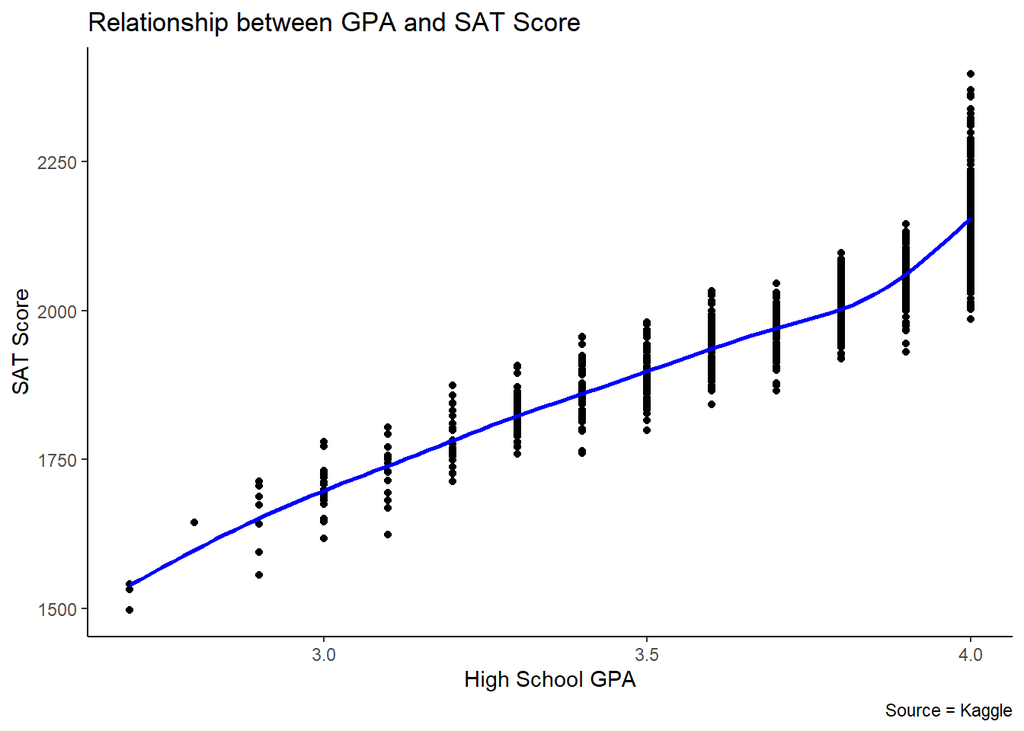

```r
ggplot(gpa,mapping = aes(x = high.school.gpa,y = SAT.total.score))+
  geom_point()+
  geom_smooth(se=FALSE, color = 'Blue')+
  labs(x = 'High School GPA', y = "SAT Score",title ='Relationship between GPA and SAT Score',caption ='Source = Kaggle')+theme_classic()
```

As you can see in the graph above, students who had higher GPAs received better scores on the SAT exam. There are distributions among each subgroup, but overall trends (blue line) show a directly proportional relationship between GPA and the SAT Score.

Does this apply to ACT as well?

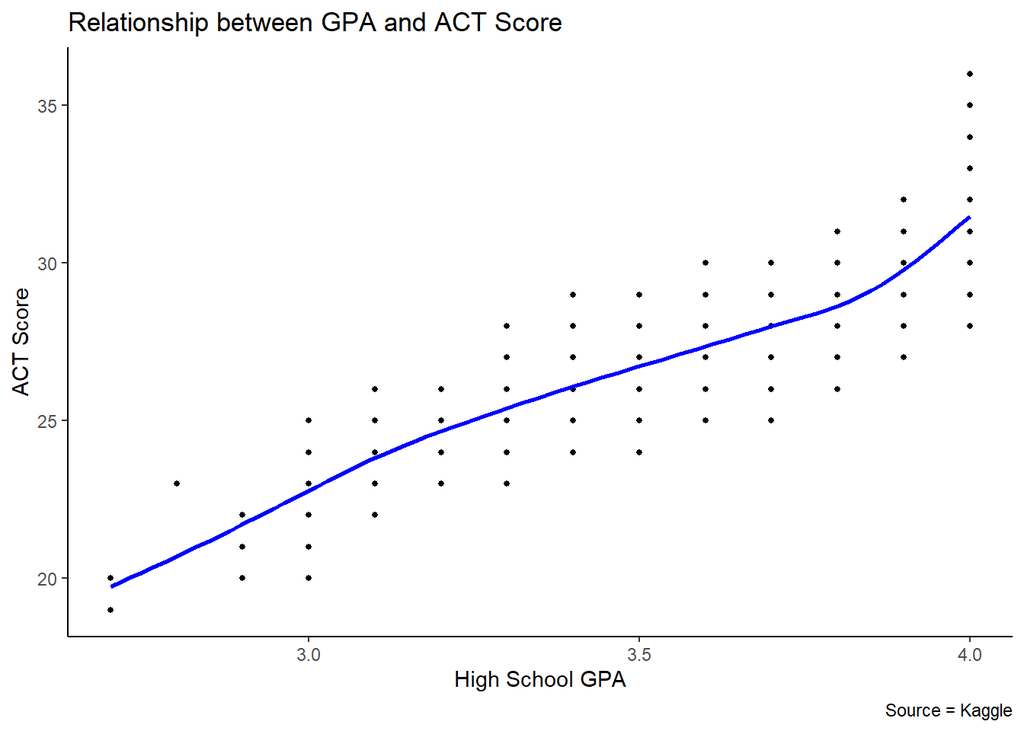

```r
ggplot(gpa,mapping = aes(x = high.school.gpa,y = ACT.composite.score))+
  geom_point(size = 1)+
  geom_smooth(se=FALSE, color = 'Blue')+
  labs(x = 'High School GPA', y = "ACT Score",title ='Relationship between GPA and ACT Score',caption ='Source = Kaggle')+theme_classic()
```

The ACT Composite Score demonstrates the same pattern as well. Students with higher GPAs showed better scores on the ACT as well.

According to the College Raptor website(source“https://www.collegeraptor.com/getting-in/articles/act-sat/average-sat-scores-what-does-the-average-student-score-on-the-sat/”), the 93% range of the SAT score is above 2000. Among the top 93% of students, I would evaluate if other factors may affect the high school GPA.

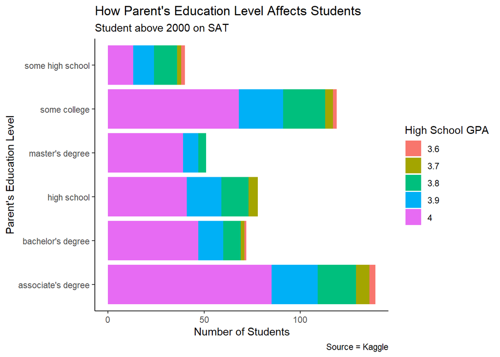

```r
gpa_above2000 <- gpa %>% filter(SAT.total.score>=2000)
gpa_above2000$high.school.gpa <- as.character(gpa_above2000$high.school.gpa)
# view(gpa_above2000)
ggplot(gpa_above2000, mapping = aes(x = parental.level.of.education,fill = high.school.gpa))+geom_bar()+
  labs(x = "Parent's Education Level",y = 'Number of Students',title = "How Parent's Education Level Affects Students",subtitle = 'Student above 2000 on SAT',caption ='Source = Kaggle',fill = 'High School GPA')+
  coord_flip()+theme_classic()
```

Lastly, I would like to see the relationship between the parent’s income and the children’s SAT scores.

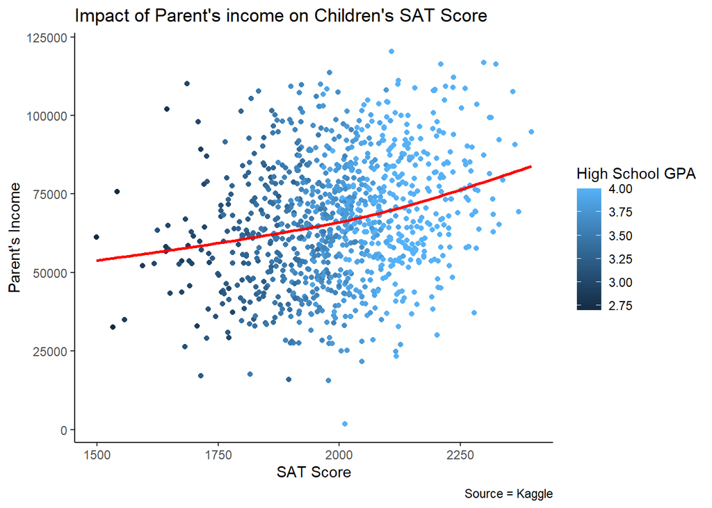

```r
ggplot(gpa, mapping = aes(x = SAT.total.score, y  = parental.income, color = high.school.gpa))+geom_point()+geom_smooth(se = FALSE, color = 'Red') + labs(x = "SAT Score", y = "Parent's Income",color = 'High School GPA', title = "Impact of Parent's income on Children's SAT Score", caption ='Source = Kaggle')+theme_classic()
```

It seems like there are slight positive direct relationship between income and SAT Score.

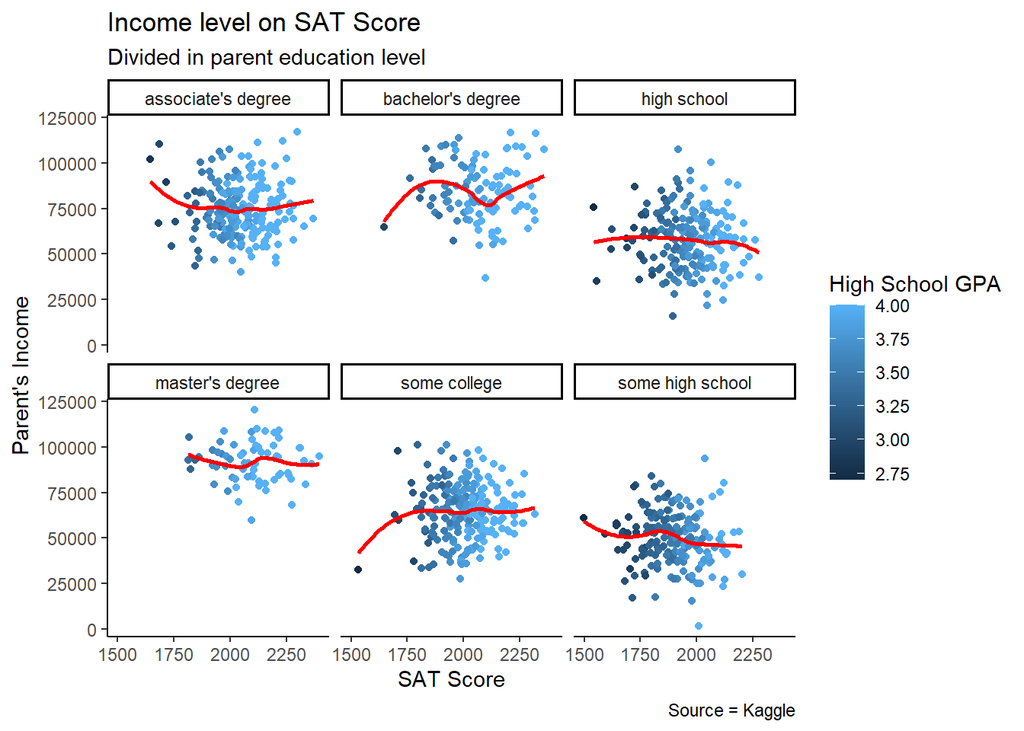

```r
ggplot(gpa, mapping = aes(x = SAT.total.score, y = parental.income,color = high.school.gpa))+geom_point()+geom_smooth(se = FALSE, color = 'red')+
  facet_wrap(~parental.level.of.education)+
  labs(x = "SAT Score",y = "Parent's Income",title = 'Income level on SAT Score', subtitle = 'Divided in parent education level',caption = 'Source = Kaggle', color = "High School GPA")+theme_classic()
```

However, when you divided into the parent’s education level and see the result, there is not enough evidence to say that there is a difference between the SAT Score and the parent’s income. Instead, parents with master’s degrees have children with higher SAT scores and higher high school GPAs as well.

To conclude, many factors are affecting the SAT scores. The most important factors that affect the SAT score are parent’s level of education and the high school GPA.